# Top 100 paid Athletes 2014

Liam Gesner

2022-08-14

Loading in data

```r
install.packages("readr",repos = "http://cran.us.r-project.org")
install.packages("tidyverse",repos = "http://cran.us.r-project.org")
install.packages("scales", repos = "http://cran.us.r-project.org")
library(tidyverse)
library(scales)
library(readr)
Athletes <- read_csv("Most-paid-athletes/Athletes.csv")
```

Manipulating Athletes data set to drop unimportant columns and add columns that can be analyzed.

```r
cols_to_drop <- c( "Wikipedia Page", "dbpedia Page", "Image", "Description")
Athletes <- Athletes[, ! names(Athletes) %in% cols_to_drop, Drop = F]
percent_Salary <- percent(parse_number(Athletes$`Salary/Winnings`)/parse_number(Athletes$`Total Pay`),accuracy = .1)
percent_Endorsements <- percent(parse_number(Athletes$Endorsements)/parse_number(Athletes$`Total Pay`),accuracy = .1)
Athletes <- cbind(Athletes, percent_Salary, percent_Endorsements)
```

Using piping to group by qualitative data

```r
by_sport <- Athletes %>%
  group_by(Sport) %>%
  mutate(percentSalaryMean = mean(parse_number((percent_Salary)))) %>%
  mutate(percentEndorsementMean = mean(parse_number(percent_Endorsements)))
by_nation <- Athletes %>%
  group_by(Nation) %>%
  mutate(percentSalaryMean = mean(parse_number((percent_Salary)))) %>%
  mutate(percentEndorsementMean = mean(parse_number(percent_Endorsements)))
```

Creating summaries for grouped data for easier analysis

```r
summ_sport <- Athletes %>%
  group_by(Sport) %>%
  summarise(
    n= n(),
    percentSalaryMean = mean(parse_number(percent_Salary), na.rm = TRUE),
    percentEndorsementMean = mean(parse_number(percent_Endorsements), na.rm = TRUE),
    heightmean = mean(`Height (cm)`, na.rm = TRUE),
    salarymeanmillions = mean(parse_number(`Total Pay`), na.rm = TRUE)/1000000
  )
summ_nation <- Athletes %>%
  group_by(Nation) %>%
  summarise(
    n= n(),
    percentSalaryMean = mean(parse_number(percent_Salary), na.rm = TRUE),
    percentEndorsementMean = mean(parse_number(percent_Endorsements), na.rm = TRUE),
    heightmean = mean(`Height (cm)`, na.rm = TRUE),
    salarymean = mean(parse_number(`Total Pay`), na.rm = TRUE)
  )
summ_age <- Athletes %>%
  group_by(`Year of birth`) %>%
  summarise(
    n= n(),
    percentSalaryMean = mean(parse_number(percent_Salary), na.rm = TRUE),
    percentEndorsementMean = mean(parse_number(percent_Endorsements), na.rm = TRUE),
    salarymean = mean(parse_number(`Total Pay`), na.rm = TRUE)
  )
summ_height <- Athletes %>%
  group_by(`Height (cm)`) %>%
  summarise(
    n= n(),
    percentSalaryMean = mean(parse_number(percent_Salary), na.rm = TRUE),
    percentEndorsementMean = mean(parse_number(percent_Endorsements), na.rm = TRUE),
  )
```

Plotted the summary of ages and found that Endorsements were a higher percentage of salary for athletes at the oldest ages and youngest ages. Which is likely because the oldest athletes have been around the longest and the youngest athletes can be promising for the future of the company they are sponsoring.

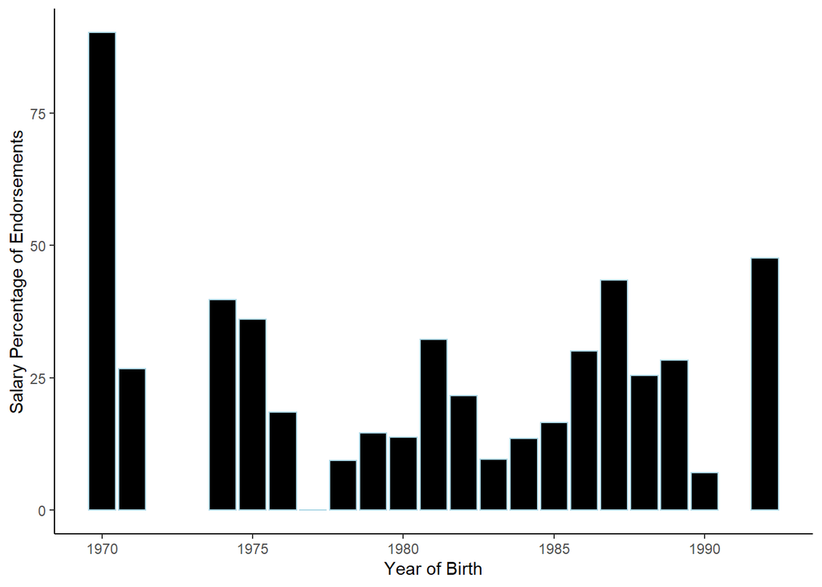

Plotted the summary of heights and found that Athletes who are short either had a very high endorsement value or almost none at all. Athletes that are tall had a more consistent endorsement value between different heights.

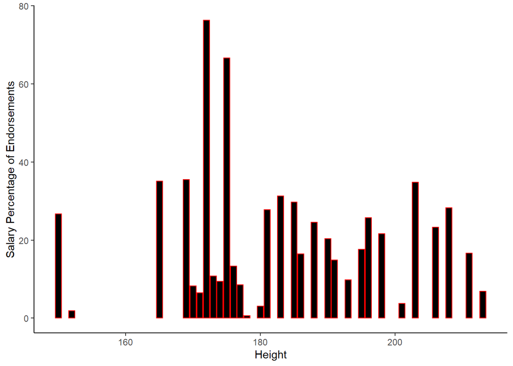

Plotted the summary of different sports and came to the conclusion that boxers had the highest salaries of the top 100 athletes. Found that, of the sports that had the most athletes on the list, (Baseball, Basketball, Football, and Soccer) soccer actually had the highest average salaries.

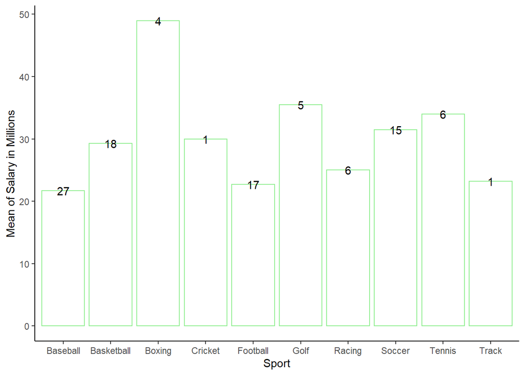